# Which Gemini Model Should You Use? Neon, Argon, Hydrogen, Carbon, Flash or Gemma. It Depends.

This article provides a step by step guide to choosing a Gemini API model by measured cost, thinking and speed. Gemini 4 Neon, announced on 2026-11-18, joins seven models measured here before: Gemma 4 26B and 31B, Gemini 3.5 Flash-Lite and 3.8 Flash, and Gemini 4 Hydrogen, Carbon and Argon. All eight answer the same questions through the same endpoint with the same scoring.

[figure not shown]

https://github.com/xbill9/gemma4-dev/tree/main/docs/gemini-which-model

The short version: on these tests the four Gemini 4 models are level on accuracy, so pick among them by cost and speed, and pick between tiers by how hard the work is.

#### The Decision Flow

Answer four questions in order and stop at the first yes.

[figure not shown]

1. **Must it be free, or run on your own hardware?** Use **Gemma 4 31B**: GSM8K 0.9735 and BFCL 0.9675, free on the Gemini API's free tier or on your own GPU.
2. **Is the work easy, such as short questions and simple function calls?** Use **3.5 Flash-Lite** for the lowest cost and fastest reply ($0.66 per 1,000 GSM8K problems, 1.10 s each), or **3.8 Flash** for a higher score (0.9788 at $1.26).
3. **Does it need high thinking, where you would otherwise use Carbon?** Use **Gemini 4 Neon at high**: Carbon's score on hard math for 0.73 times the cost.
4. **Is response time the priority?** Use **Gemini 4 Hydrogen at its lowest setting**: 30 of 30 hard problems at 11.3 s each, the fastest Gemini 4 model.
5. **Otherwise** use **Gemini 4 Argon at its lowest setting**: 30 of 30 hard problems at $0.018 each, the cheapest Gemini 4 model. From 2026-12-01, when Argon's price doubles, Hydrogen is cheaper ($0.026 against $0.036).

For the best function-calling score, Neon leads at 0.9750, level with Argon and Gemma 4 31B at 0.9675. The steps below show where each number comes from.

#### The Findings

**Accuracy.** Hydrogen, Carbon, Argon and Neon solved all 30 AIME 2025 problems at their lowest thinking setting and again at their high setting. On these problems no Gemini 4 model can be ranked above another. The smaller models can: Flash-Lite solved 18 of 30 at its lowest setting, and Argon solved the 12 it missed and lost none (exact test, p < 0.001).

**Thinking.** Raising the setting bought nothing on Gemini 4 (30 of 30 either way) for 1.9 to 4.6 times the cost. It paid on the smallest paid model: Flash-Lite went from 18 to 24 of 30 (+6 / −0, p = 0.031) for 2.6 times the cost.

**Speed.** With every model running at the same time on AIME 2025 II, Hydrogen was the fastest Gemini 4 model at its lowest setting (11.3 s median per problem) and Neon the slowest (40.8 s).

**Neon against Carbon.** At high thinking, the setting Google compares them at, Neon cost 0.73 times Carbon per problem, cheaper on 13 of 15 problems (paired test, p < 0.001), with the same 15 of 15 on AIME 2025 II. Its median time was 0.68 times Carbon's, but it was faster on only 9 of 15 problems, which could be chance. Google states 32% lower cost per task than Carbon on the Artificial Analysis Intelligence Index.

**What to do with it.**

- 🟢 Default to Gemini 4 Argon at its lowest setting: every hard problem solved, the lowest cost of the Gemini 4 models.
- 🟢 Use Hydrogen when response time matters most, and from 2026-12-01, when Argon's price doubles, for cost too.
- 🟢 Use Neon in place of Carbon for work that needs high thinking.
- ⚠️ Use Flash-Lite only on easy work, or at high thinking.
- ⚠️ Use Gemma 4 when the model must be free or run on your own hardware.

**Caveats.** AIME 2025 has been public since early 2025, so some models may have seen these problems in training; that would raise every Gemini 4 score alike and is untested here. On 30 problems near 90% right, a gap has to be about 15 points before it can be told from chance, so close scores here are ties. Google positions Neon and Carbon for long agent and coding work, which none of these tests measures.

#### What Was Measured

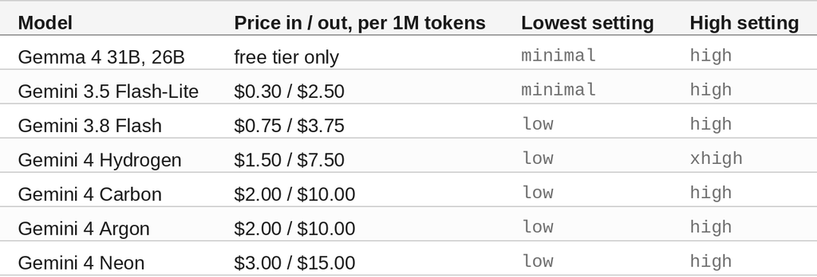

Output prices include thinking tokens. Carbon and Argon go to $4 / $20 on 2026-12-01. Neon is paid tier only. 3.8 Flash and the Gemini 4 models accept `none` and run it as `low`; Neon was sent `low` on AIME 2025 I and `none` elsewhere and thought on every problem either way. Hydrogen's high setting is its top, `xhigh`; Neon's is `high`, Google's default for it.

Three tests, each scored in code, temperature 0:

- **GSM8K**, 1,319 short math word problems, and **BFCL simple**, 400 function calls, at the lowest setting. Seven models ran together on 2026-11-14; Neon ran on 2026-11-19 with the same settings, alone.
- **AIME 2025 I**, 15 competition problems, 32,768-token limit, both settings, 2026-11-15 (Neon 2026-11-19).
- **AIME 2025 II**, the other 15, same limit, both settings, all models started at the same time on 2026-11-19. Its times are the ones compared below.

Costs are the tokens each reply reported times the list price.

#### Step 1 — Short Problems: Everyone Scores, Price Differs

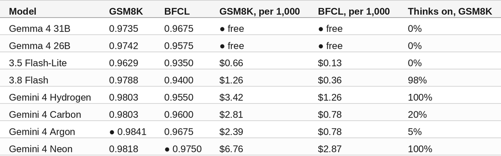

Neon's GSM8K score is level with 3.8 Flash and every Gemini 4 model and ahead of both Gemma 4 models and Flash-Lite. Its BFCL score is ahead of Hydrogen, 3.8 Flash and Flash-Lite and level with Carbon, Argon and Gemma 4 31B. Each comparison is an exact paired test by question, and "ahead" means p < 0.05.

Hydrogen and Neon think on every request even at their lowest setting, and that sets the bill: Neon cost 2.8 times Argon per GSM8K problem.

#### Step 2 — Hard Problems: Gemini 4 Solves Them All

AIME 2025 I and II together, 30 problems:

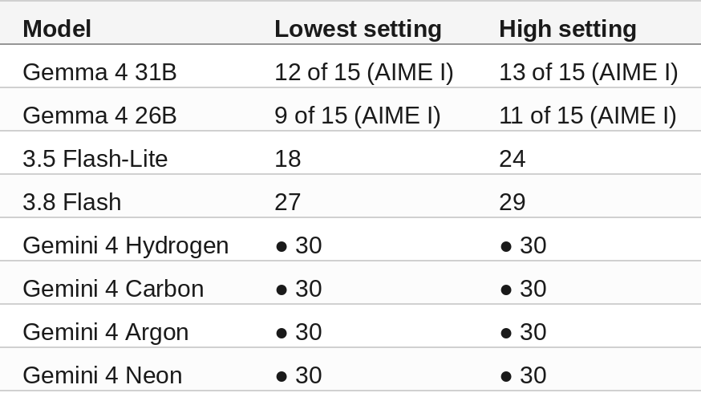

Gemma 4 on the free tier is shown for AIME I only.

With 30 of 30 the 95% range on each Gemini 4 score is 0.89 to 1.00, so these problems show that all four solve them and cannot say which solves them best. 3.8 Flash at its lowest setting missed 3 that Argon solved; on 30 problems that could be chance (p = 0.25).

#### Step 3 — Thinking: Pay for It Only on the Small Model

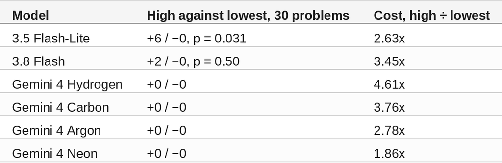

Mean thinking per hard problem at the lowest setting was 118 tokens on Argon, 542 on Carbon, 2,314 on Neon and 2,406 on Hydrogen. Argon and Carbon decide on their own how much to think, and on most problems they barely do.

Median seconds per AIME 2025 II problem, every model running at the same time:

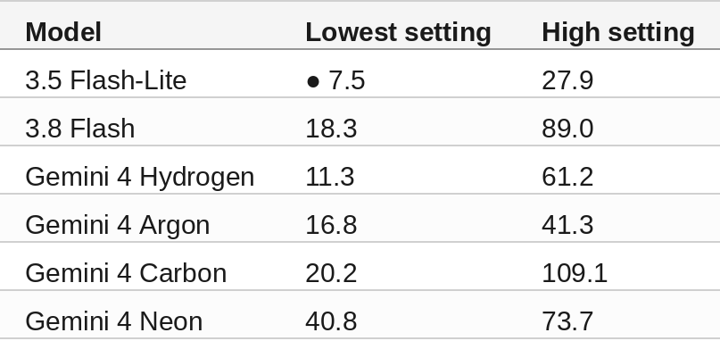

On short problems, in the 2026-11-14 run of the first seven models together: Flash-Lite 1.10 s per GSM8K problem, Hydrogen 2.84 s, 3.8 Flash 3.79 s, Carbon 7.34 s and Argon 7.63 s.

#### Step 5 — Neon Against Carbon

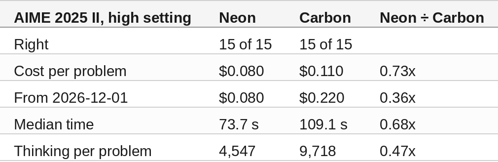

Neon reaches the same answers as Carbon with half the thinking, and was cheaper on 13 of the 15 problems. It was faster on 9 of 15, so the time difference could be chance. Argon at the same setting cost $0.048 a problem and took 41.3 s for the same 15.

#### 🔎 Tip: Compare Models by Cost per Right Answer

List price per token misleads. Hydrogen has the lowest Gemini 4 price and Argon cost less per hard problem at the lowest setting ($0.018 against $0.026), because Argon thought on few problems and Hydrogen on all of them. Run 20 to 50 of your own requests on each candidate and divide the bill by the number right.

#### Compare and Contrast

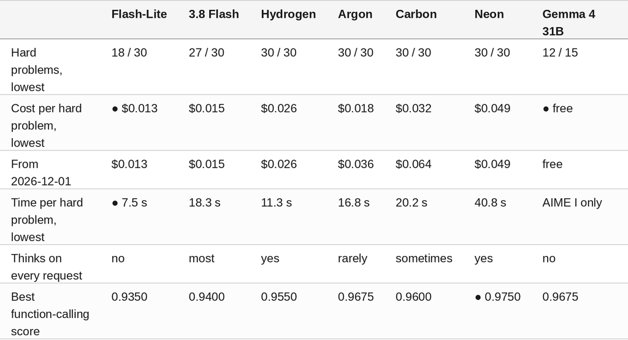

#### So, Which One?

[figure not shown]

#### Summary

The goal of this article was to place every Gemini API model, Neon included, by what it gets right, what it costs and how fast it answers. The key to the solution was one scoring script, one endpoint and the same questions for all eight models. The results were:

- 🟢 Hydrogen, Carbon, Argon and Neon solved all 30 AIME 2025 problems at their lowest setting.
- 🟢 Argon cost the least of them per problem, $0.018; Hydrogen answered fastest, 11.3 s.
- 🟢 Neon matched Carbon at high thinking for 0.73 times the cost.
- 🟢 Neon has the best function-calling score, 0.9750, level with Argon and Gemma 4 31B.
- 🟢 High thinking lifted Flash-Lite from 18 to 24 of 30.
- ⚠️ High thinking added nothing on Gemini 4 for 1.9 to 4.6 times the cost.
- ⚠️ Neon thinks on every request and cost 2.7 to 2.8 times Argon at the lowest setting.
- ❌ These problems cannot rank the Gemini 4 models on accuracy.

Scope: one run per model and setting, temperature 0, through the Gemini API's OpenAI-compatible endpoint, between 2026-11-14 and 2026-11-19, at list prices on those dates. GSM8K and BFCL simple at the lowest setting only; 30 AIME 2025 problems at two settings, with Gemma 4 on AIME 2025 I only. Times compare only within one run. Long agent work, coding, and tests harder than AIME 2025 were not measured.

The strategy for choosing a Gemini model by measured cost, thinking and speed was validated with an incremental step by step approach.

#### References

- [Evidence for this article](https://github.com/xbill9/gemma4-dev/tree/main/docs/gemini-which-model/evidence)
- [Introducing Gemini 4 Neon](https://blog.google/innovation-and-ai/models-and-research/gemini-models/introducing-gemini-4-neon/)
- [Gemini API pricing](https://aistudio.google.com/docs/pricing)
- [Gemini 4 or Gemma 4? It Depends.](https://dev.to/gde/gemini-4-or-gemma-4-it-depends-2o18)
- [Which Model Should You Use? Frontier, Hosted or Local? It Depends.](https://dev.to/gde/which-model-should-you-use-frontier-hosted-or-local-it-depends-2n45)
- [AIME 2025 problems (opencompass/AIME2025)](https://huggingface.co/datasets/opencompass/AIME2025)
- [gemma4-dev on GitHub](https://github.com/xbill9/gemma4-dev)

Hope you enjoyed it!